# Pilgrim Bank B: Classification with R

## 0. Load data and define target (dependent) variable

- Use pilgrim bank extended dataset
- We are interested in whether the customer is retained
  - i.e. are they present in 2000
  - Easily created with the true/false function is.na

```r
dta <- read.csv("extended_data.csv")
dta$District9 <- as.factor(dta$District9)
dta$y <- rep(0,length(dta$Profit9))
dta$y[!is.na(dta$Profit0)] <- 1
# dta$y <- !is.na(dta$Profit0)
dta$AgeExists <- 1 - dta$MissingAge
dta$IncExists <- 1 - dta$MissingInc
```

## 1. Generate a training and test set.

- first calculate the sample size
  - 75% of the rows in the data set
  - nrow(dta) returns the number of rows in the ‘data’ data-frame

```r
smp_size <- floor(0.75 * nrow(dta))
smp_size
```

```
## [1] 23725
```

- generate the indices for the training set
  - note, 1:nrow(dta) gives a list of all indices e.g. [1,2,3,4..,nrow(dta)]

```r
train_ind <- sample(1:nrow(dta), size = smp_size)
```

- make the tranining and test sets by slicing the original data set

```r
train <- dta[train_ind, ]
test <- dta[-train_ind, ]
```

## 2. Generate a classifier

- Use logistical regression on training set to create a classification model
- y~x1+x2+… is the regression formula exactly of the same form as for a linear regression
- by setting dta=train we are using **only the training data** to build the classification model

```r
cls <- glm(y~Profit9+Online9+AgeImpt+IncImpt+AgeExists+District9+Billpay9, family='binomial',data=train)
summary(cls)
```

```
##
## Call:
## glm(formula = y ~ Profit9 + Online9 + AgeImpt + IncImpt + AgeExists +
##     District9 + Billpay9, family = "binomial", data = train)
##
## Deviance Residuals:
##     Min       1Q   Median       3Q      Max
## -2.7212   0.3151   0.3861   0.4675   1.3093
##
## Coefficients:
##                 Estimate Std. Error z value Pr(>|z|)
## (Intercept)   -7.587e-01  1.052e-01  -7.211 5.56e-13 ***
## Profit9        3.381e-04  8.278e-05   4.084 4.42e-05 ***
## Online9        2.192e-01  6.675e-02   3.283  0.00103 **
## AgeImpt        1.872e-01  1.709e-02  10.949  < 2e-16 ***
## IncImpt        5.271e-02  1.206e-02   4.371 1.23e-05 ***
## AgeExists      2.120e+00  3.881e-02  54.629  < 2e-16 ***
## District91200  9.593e-02  6.515e-02   1.473  0.14086
## District91300  7.477e-02  7.808e-02   0.958  0.33828
## Billpay9      -6.710e-01  1.535e-01  -4.372 1.23e-05 ***
## ---
## Signif. codes:  0 '***' 0.001 '**' 0.01 '*' 0.05 '.' 0.1 ' ' 1
##
## (Dispersion parameter for binomial family taken to be 1)
##
##     Null deviance: 21256  on 23724  degrees of freedom
## Residual deviance: 17708  on 23716  degrees of freedom
## AIC: 17726
##
## Number of Fisher Scoring iterations: 5
```

## 3. Assess training error

- Define the cut as the threshold where a glm probability prediction less than the cut is classified as a False (not retained) and a probability greater that the cut is classified as a True (Retained)

```r
cut=0.5
```

- Store the predicted classes in yhat
- Calculate error by comparing the true values with classified values

```r
yhat = (cls$fit>cut)
tr.err = mean( train$y!=yhat )
tr.err
```

```
## [1] 0.1655216
```

## 4. Assess test error

- We can similarly assess testing error but we need to use predict to determine the classified values for the test set
- The predict function for a glm model requires specifying the type of prediction
  - for a probability prediction use type=“response”

```r
yhat = (predict(cls,test,type="response")>cut)
te.err = mean( test$y!=yhat )
te.err
```

```
## [1] 0.1668985
```

**Here is what yhat for the testing error looks like**

```r
summary(yhat)
```

```
##    Mode   FALSE    TRUE
## logical      28    7881
```

## 5. How does misclassification depends on this threshold

- I’ve written some functions to help evaluate classification error
- They include calculations of the sensitivity, specificity, and classification rate
- Read in the classification script (needs to be in the working directory)

```r
source("classification_functions.R")
```

- check different error on the training and testing data

```r
perf(cut,cls,train,train$y)
```

```
##   threshold sensitivity specificity        tp        fp          tn          fn
## 1       0.5   0.9977283 0.008682329 0.9977283 0.9913177 0.008682329 0.002271695
##     prob_tp   prob_fp     prob_tn     prob_fn  accuracy
## 1 0.8330453 0.1636249 0.001433087 0.001896733 0.8344784
```

```r
perf(cut,cls,test,test$y)
```

```
##   threshold sensitivity specificity        tp        fp         tn          fn
## 1       0.5   0.9980264  0.01134644 0.9980264 0.9886536 0.01134644 0.001973584
##    prob_tp   prob_fp     prob_tn     prob_fn  accuracy
## 1 0.831205 0.1652548 0.001896574 0.001643697 0.8331015
```

- Plot for different threshold values

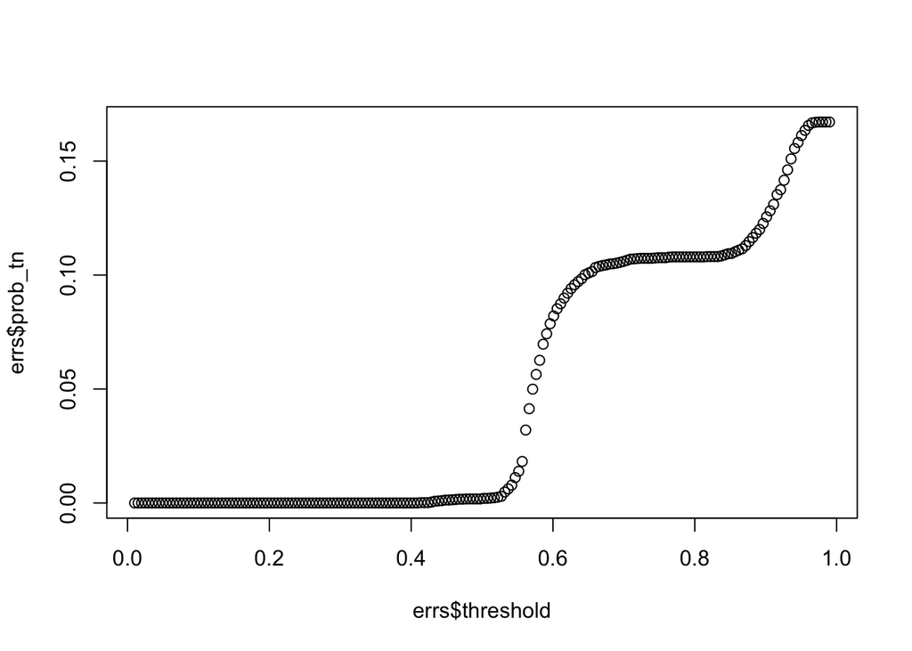

```r
errs <- thresholds(cls,test,test$y)
plot(errs$threshold,errs$prob_tn)
```

## 6. Other classifiers: Support Vector Machines

- Must install the package from the cran repository

```r
install.packages("e1071")
```

- load the package
- can also be installed in rstudio using the menu Tools/Install Packages…
- build a model as with glm or lm
  - But… y needs to be a factor for svm to do classification (otherwise svm does regression)

```r
train$ySVM <- as.factor(train$y)
test$ySVM <- as.factor(test$y)
cls2 <- svm(ySVM~Profit9+Online9+AgeImpt+IncImpt+AgeExists+District9+Billpay9, data = train)
yhat <- predict(cls2, test)
mean( test$ySVM!=yhat )
```

```
## [1] 0.1671513
```

## 7. Other classifiers: Tree Classifier

- Tree classifiers are in the package rpart

```r
install.packages("rpart")
```

- Build tree classifier
  - I removed variables so that we could visualize it better

```r
library(rpart)
cls3 <- rpart(y~Online9+IncImpt+AgeExists+District9+Billpay9,method="class",data=train,cp=0.0025)
printcp(cls3) # display the results
```

```
##
## Classification tree:
## rpart(formula = y ~ Online9 + IncImpt + AgeExists + District9 +
##     Billpay9, data = train, method = "class", cp = 0.0025)
##
## Variables actually used in tree construction:
## [1] AgeExists IncImpt
##
## Root node error: 3916/23725 = 0.16506
##
## n= 23725
##
##          CP nsplit rel error xerror     xstd
## 1 0.0042560      0   1.00000 1.0000 0.014602
## 2 0.0032346      6   0.97446 1.0059 0.014636
## 3 0.0025000      9   0.96476 1.0018 0.014612
```

- Visualize the splits

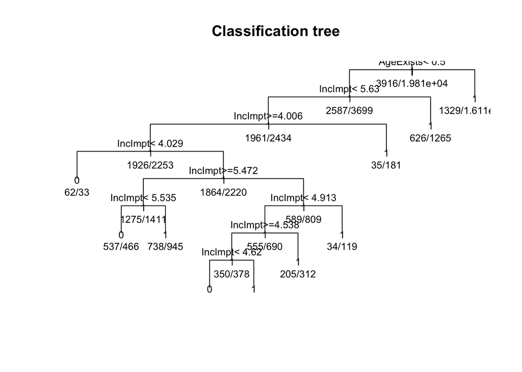

```r
plot(cls3, uniform=TRUE,
   main="Classification tree")
text(cls3, use.n=TRUE, all=TRUE, cex=.8)
```

* Finally, how is it working?

```r
yhat <- predict(cls3,test,type="class")
mean( test$y!=yhat )
```

```
## [1] 0.1580478
```